# GASP! A Genomic Atlas of Scottish Pectobacterium

04/08/2017

## *Pectobacterium* = blackleg

The bacterium *P. atrosepticum* (*Pba*) causes blackleg/softrot

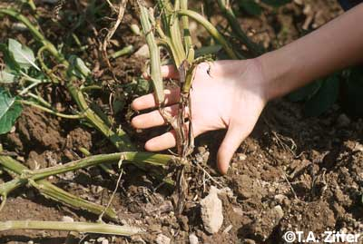

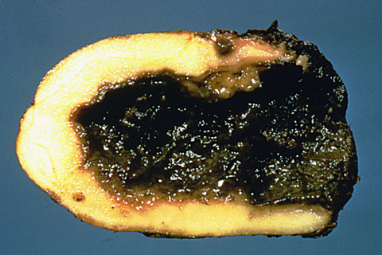

- Major cause of downgrading and rejections

**Where does infection come from?** We need to track *Pba*

- identifying pathogen origin enables control measure development

## Overview

**We aim to make a historical, genomic atlas of Scottish *Pba*.**

- Long-term account of *Pba* in Scottish soils/farms
- Provide background for better detection of new pathogen introductions
- More precise and accurate diagnostics
  - improved tracking of *Pba*
  - enable development of improved control measures

**Total requested support: £8000**  
To sequence ≈20% of our *Pba* isolate collection at JHI

- sequencing costs (100 isolates): £7000
- consumables: £1000
- staff time in kind (supporting RESAS work packages)

## *P. atrosepticum* diagnostics

*Pba* is a single species with closely-related isolates

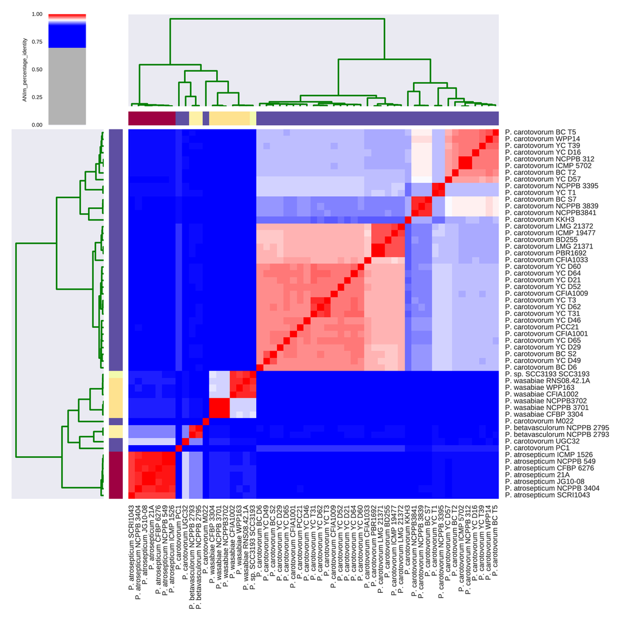

- Single diagnostic for all *Pba* (ECA primers); MLST, VNTR for subgroups

**Genome data allows individualisation.**

## *P. atrosepticum* genomes: NCBI

**Seven complete genomes at NCBI: global distribution**

[output not shown]

## *P. atrosepticum* genomes: Scotland

**Sequenced ≈50 new *Pba* isolates from NE Scotland**

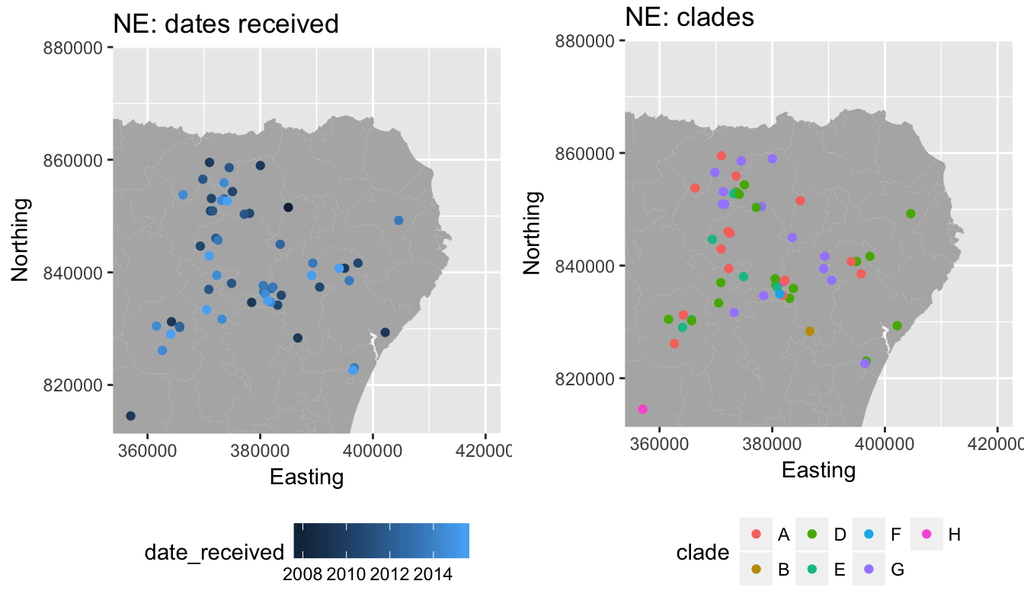

- Spanning six years, all known MLST clades

## We got a surprise…

**Four groups (clades) of *Pba* identified in Scotland (+NCBI isolates)**

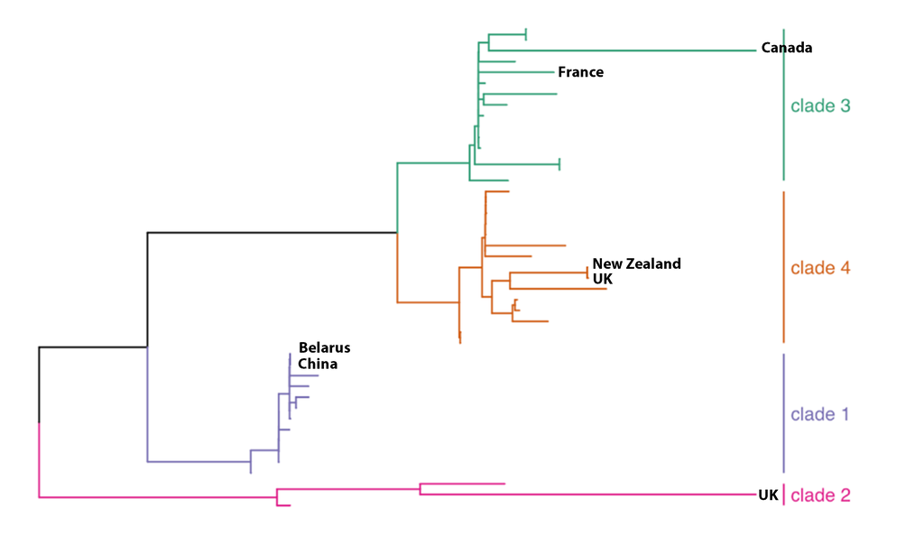

**Genome diversity of *Pba* in NE Scotland > global *Pba* genome diversity**

## Another surprise…

*Pba* groups widespread across NE Scotland, little/no 'interbreeding'

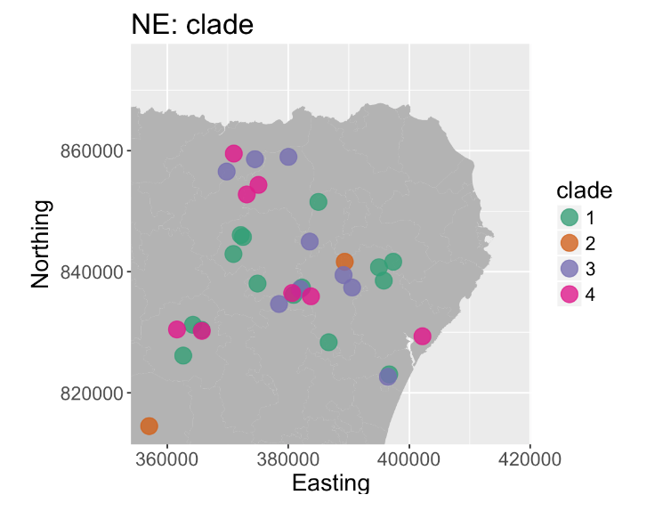

**This raises several important questions…**

## Unanswered questions

- **Why are there *any* distinct groups of *Pba*?**
  - shouldn't they 'mix' more in a small geographical area?
  - were all *Pba* carried in on recent introductions?
  - do *Pba* variants coexist worldwide in mixed communities?
- **If *Pba* introduced from elsewhere…**
  - can we date earliest introduction?
  - can we track, or identify nation/continent of origin?
- **If *Pba* naturally present and mixed worldwide…**
  - what is natural diversity across Scotland?
  - can we use this background to detect new local introductions?
- **Can we use data to develop more accurate diagnostics?**

**Help to answer these questions by sequencing our *Pba* collection**

## JHI Collection

**We hold ≈500 historical *Pba* isolates at JHI**

- Isolates from ≈1950 to present day
- Mostly from Scotland
  - also Europe, North & South America, Asia

**Sequence ≈100 isolates, to make a historical atlas of Scottish *Pba*.**

- Long-term account of *Pba* in Scottish soils, mapped to region
  - understand history and transfer of *Pba* in Scotland
- Provide background for better detection of new pathogen introductions
- Provide a basis for more precise and accurate diagnostics
  - enable development of improved control measures